# Return Home

View Code on Github

# News Channels Youtube Data EDA

## 1 Marvel Entertainment

Marvel is committed to bringing great stories, characters, and experiences to fans all over the world. We strive to foster an inclusive, diverse, respectful, and safe environment for all of our fans, and we ask the same of our fan communities

## 4 BET

is your home for all the latest celebrity, music, fashion, entertainment and African-American news

## 5 20th Century Studios

is an American film studio currently owned by the Walt Disney Studios, a division of Disney Entertainment, in turn a division of The Walt Disney Company. It is headquartered at the Fox Studio Lot in the Century City area of Los Angeles

## 6 Paramount Pictures

is an American film and television production and distribution company and the namesake division of Paramount Global.

## 1 Marvel Entertainment

## Function to get Marvel Entertainment channel statistics

```python
# lets import libraries
from googleapiclient.discovery import build
import pandas as pd
import seaborn as sns
```

```python
api_key = 'AIzaSyB24Kop04L1GlTgRCm1XtQ4KB2a4gaBOwA'
Marvel_Entertainment_channel_id = ['UCvC4D8onUfXzvjTOM-dBfEA' # Marvel Entertainment

              ]
youtube = build('youtube','v3',developerKey = api_key)

from googleapiclient.errors import HttpError

def get_channel_stats(youtube, Marvel_Entertainment_channel_id):
    all_data = []
    try:
        request = youtube.channels().list(
            part='snippet,contentDetails,statistics',
            id=','.join(Marvel_Entertainment_channel_id)
        )
        response = request.execute()

        for item in response.get('items', []):
            snippet = item.get('snippet', {})
            statistics = item.get('statistics', {})

            data = {
                'Channel_name': snippet.get('title', ''),
                'Subscribers': statistics.get('subscriberCount', ''),
                'Views': statistics.get('viewCount', ''),
                'Total_videos': statistics.get('videoCount', '')
            }

            all_data.append(data)

    except HttpError as e:
        print(f"HTTP error occurred: {e}")
        print(f"Request URL: {e.resp.request.url}")
        print(f"Request body: {e.resp.request.body}")

    return all_data
```

```python
get_channel_stats(youtube, Marvel_Entertainment_channel_id)
```

```
[{'Channel_name': 'Marvel Entertainment',
  'Subscribers': '20300000',
  'Views': '5855379161',
  'Total_videos': '8854'}]
```

```python
Marvel_Entertainment_channel_statistics = get_channel_stats(youtube, Marvel_Entertainment_channel_id)
```

```python
Marvel_Entertainment_channel_data =pd.DataFrame(Marvel_Entertainment_channel_statistics)
```

```python
Marvel_Entertainment_channel_data
```

|  | Channel_name | Subscribers | Views | Total_videos |
| --- | --- | --- | --- | --- |
| 0 | Marvel Entertainment | 20300000 | 5855379161 | 8854 |

## 2 Hulu Studios

## Function to get Hulu Studios channel statistics

```python
api_key = 'AIzaSyB24Kop04L1GlTgRCm1XtQ4KB2a4gaBOwA'
Hulu_Studios_channel_id = ['UCE5mQnNl8Q4H2qcv4ikaXeA' # Hulu_Studios

              ]
youtube = build('youtube','v3',developerKey = api_key)

from googleapiclient.errors import HttpError

def get_channel_stats(youtube, Hulu_Studios_channel_id):
    all_data = []
    try:
        request = youtube.channels().list(
            part='snippet,contentDetails,statistics',
            id=','.join(Hulu_Studios_channel_id)
        )
        response = request.execute()

        for item in response.get('items', []):
            snippet = item.get('snippet', {})
            statistics = item.get('statistics', {})

            data = {
                'Channel_name': snippet.get('title', ''),
                'Subscribers': statistics.get('subscriberCount', ''),
                'Views': statistics.get('viewCount', ''),
                'Total_videos': statistics.get('videoCount', '')
            }

            all_data.append(data)

    except HttpError as e:
        print(f"HTTP error occurred: {e}")
        print(f"Request URL: {e.resp.request.url}")
        print(f"Request body: {e.resp.request.body}")

    return all_data
```

```python
get_channel_stats(youtube, Hulu_Studios_channel_id)
```

```
[{'Channel_name': 'Hulu',
  'Subscribers': '2310000',
  'Views': '784639767',
  'Total_videos': '2767'}]
```

```python
Hulu_Studios_channel_statistics = get_channel_stats(youtube, Hulu_Studios_channel_id)
```

```python
Hulu_Studios_channel_data =pd.DataFrame(Hulu_Studios_channel_statistics)
```

```python
Hulu_Studios_channel_data
```

|  | Channel_name | Subscribers | Views | Total_videos |
| --- | --- | --- | --- | --- |
| 0 | Hulu | 2310000 | 784639767 | 2767 |

## 3 OWN

## Function to get OWN channel statistics

```python
api_key = 'AIzaSyB24Kop04L1GlTgRCm1XtQ4KB2a4gaBOwA'
OWN_channel_id = ['UCKBnlTTgEnhIXv_c4LvvyMQ' # OWN

              ]
youtube = build('youtube','v3',developerKey = api_key)

from googleapiclient.errors import HttpError

def get_channel_stats(youtube, OWN_channel_id):
    all_data = []
    try:
        request = youtube.channels().list(
            part='snippet,contentDetails,statistics',
            id=','.join(OWN_channel_id)
        )
        response = request.execute()

        for item in response.get('items', []):
            snippet = item.get('snippet', {})
            statistics = item.get('statistics', {})

            data = {
                'Channel_name': snippet.get('title', ''),
                'Subscribers': statistics.get('subscriberCount', ''),
                'Views': statistics.get('viewCount', ''),
                'Total_videos': statistics.get('videoCount', '')
            }

            all_data.append(data)

    except HttpError as e:
        print(f"HTTP error occurred: {e}")
        print(f"Request URL: {e.resp.request.url}")
        print(f"Request body: {e.resp.request.body}")

    return all_data
```

```python
get_channel_stats(youtube, OWN_channel_id)
```

```
[{'Channel_name': 'OWN',
  'Subscribers': '5730000',
  'Views': '2912620718',
  'Total_videos': '19550'}]
```

```python
OWN_channel_statistics = get_channel_stats(youtube, OWN_channel_id)
```

```python
OWN_channel_data =pd.DataFrame(OWN_channel_statistics)
```

```python
OWN_channel_data
```

|  | Channel_name | Subscribers | Views | Total_videos |
| --- | --- | --- | --- | --- |
| 0 | OWN | 5730000 | 2912620718 | 19550 |

## Function to get BET channel statistics

```python
api_key = 'AIzaSyB24Kop04L1GlTgRCm1XtQ4KB2a4gaBOwA'
BET_channel_id = ['UCKBnlTTgEnhIXv_c4LvvyMQ' # BET

              ]
youtube = build('youtube','v3',developerKey = api_key)

from googleapiclient.errors import HttpError

def get_channel_stats(youtube, BET_channel_id ):
    all_data = []
    try:
        request = youtube.channels().list(
            part='snippet,contentDetails,statistics',
            id=','.join(BET_channel_id )
        )
        response = request.execute()

        for item in response.get('items', []):
            snippet = item.get('snippet', {})
            statistics = item.get('statistics', {})

            data = {
                'Channel_name': snippet.get('title', ''),
                'Subscribers': statistics.get('subscriberCount', ''),
                'Views': statistics.get('viewCount', ''),
                'Total_videos': statistics.get('videoCount', '')
            }

            all_data.append(data)

    except HttpError as e:
        print(f"HTTP error occurred: {e}")
        print(f"Request URL: {e.resp.request.url}")
        print(f"Request body: {e.resp.request.body}")

    return all_data
```

```python
get_channel_stats(youtube, BET_channel_id)
```

```
[{'Channel_name': 'OWN',
  'Subscribers': '5730000',
  'Views': '2912620718',
  'Total_videos': '19550'}]
```

```python
BET_channel_statistics = get_channel_stats(youtube, BET_channel_id)
```

```python
BET_channel_data =pd.DataFrame(BET_channel_statistics)
```

```python
BET_channel_data
```

[output not shown]

## 5 20th Century Studios

## Function to get 20th Century Studios channel statistics

```python
api_key = 'AIzaSyB24Kop04L1GlTgRCm1XtQ4KB2a4gaBOwA'
Century_Studios_channel_id = ['UC2-BeLxzUBSs0uSrmzWhJuQ' # 20th Century Studios

              ]
youtube = build('youtube','v3',developerKey = api_key)

from googleapiclient.errors import HttpError

def get_channel_stats(youtube, Century_Studios_channel_id):
    all_data = []
    try:
        request = youtube.channels().list(
            part='snippet,contentDetails,statistics',
            id=','.join(Century_Studios_channel_id )
        )
        response = request.execute()

        for item in response.get('items', []):
            snippet = item.get('snippet', {})
            statistics = item.get('statistics', {})

            data = {
                'Channel_name': snippet.get('title', ''),
                'Subscribers': statistics.get('subscriberCount', ''),
                'Views': statistics.get('viewCount', ''),
                'Total_videos': statistics.get('videoCount', '')
            }

            all_data.append(data)

    except HttpError as e:
        print(f"HTTP error occurred: {e}")
        print(f"Request URL: {e.resp.request.url}")
        print(f"Request body: {e.resp.request.body}")

    return all_data
```

```python
get_channel_stats(youtube, Century_Studios_channel_id )
```

```
[{'Channel_name': '20th Century Studios',
  'Subscribers': '4680000',
  'Views': '2933613571',
  'Total_videos': '2728'}]
```

```python
channel_statistics = get_channel_stats(youtube, Century_Studios_channel_id )
```

```python
Century_Studios_channel_data =pd.DataFrame(channel_statistics)
```

```python
Century_Studios_channel_data
```

|  | Channel_name | Subscribers | Views | Total_videos |
| --- | --- | --- | --- | --- |
| 0 | 20th Century Studios | 4680000 | 2933613571 | 2728 |

## Function to get Paramount Pictures channel statistics

```python
api_key = 'AIzaSyB24Kop04L1GlTgRCm1XtQ4KB2a4gaBOwA'
Paramount_Pictures_channel_id = ['UCF9imwPMSGz4Vq1NiTWCC7g' # Paramount Pictures

              ]
youtube = build('youtube','v3',developerKey = api_key)

from googleapiclient.errors import HttpError

def get_channel_stats(youtube, Paramount_Pictures_channel_id):
    all_data = []
    try:
        request = youtube.channels().list(
            part='snippet,contentDetails,statistics',
            id=','.join(Paramount_Pictures_channel_id)
        )
        response = request.execute()

        for item in response.get('items', []):
            snippet = item.get('snippet', {})
            statistics = item.get('statistics', {})

            data = {
                'Channel_name': snippet.get('title', ''),
                'Subscribers': statistics.get('subscriberCount', ''),
                'Views': statistics.get('viewCount', ''),
                'Total_videos': statistics.get('videoCount', '')
            }

            all_data.append(data)

    except HttpError as e:
        print(f"HTTP error occurred: {e}")
        print(f"Request URL: {e.resp.request.url}")
        print(f"Request body: {e.resp.request.body}")

    return all_data
```

```python
get_channel_stats(youtube, Paramount_Pictures_channel_id)
```

```
[{'Channel_name': 'Paramount Pictures',
  'Subscribers': '3290000',
  'Views': '2506983750',
  'Total_videos': '1799'}]
```

```python
Paramount_Pictures_channel_statistics = get_channel_stats(youtube, Paramount_Pictures_channel_id)
```

```python
Paramount_Pictures_channell_data =pd.DataFrame(channel_statistics)
```

```python
Paramount_Pictures_channell_data
```

[output not shown]

```python
# Combine DataFrames using concat
combined_movie_studios_channels_df= pd.concat([Marvel_Entertainment_channel_data ,
                                       Hulu_Studios_channel_data,
                                       OWN_channel_data ,
                                      BET_channel_data ,
                                    Century_Studios_channel_data,
                                      Paramount_Pictures_channell_data,


                                      ], ignore_index=True)

# Display the result
print(combined_movie_studios_channels_df)
```

[output not shown]

```python
# letc change the data types
combined_movie_studios_channels_df.info()
```

```
<class 'pandas.core.frame.DataFrame'>
RangeIndex: 6 entries, 0 to 5
Data columns (total 4 columns):
 #   Column        Non-Null Count  Dtype
---  ------        --------------  -----
 0   Channel_name  6 non-null      object
 1   Subscribers   6 non-null      object
 2   Views         6 non-null      object
 3   Total_videos  6 non-null      object
dtypes: object(4)
memory usage: 324.0+ bytes
```

```python
# lets change the datatypes to perform  visualisations
combined_movie_studios_channels_df['Subscribers'] = pd.to_numeric(combined_movie_studios_channels_df['Subscribers'])
combined_movie_studios_channels_df['Views'] = pd.to_numeric(combined_movie_studios_channels_df['Views'])
combined_movie_studios_channels_df['Total_videos'] = pd.to_numeric(combined_movie_studios_channels_df['Total_videos'])
# letsconirm if the datatypes has changed
combined_movie_studios_channels_df.info()
```

```
<class 'pandas.core.frame.DataFrame'>
RangeIndex: 6 entries, 0 to 5
Data columns (total 4 columns):
 #   Column        Non-Null Count  Dtype
---  ------        --------------  -----
 0   Channel_name  6 non-null      object
 1   Subscribers   6 non-null      int64
 2   Views         6 non-null      int64
 3   Total_videos  6 non-null      int64
dtypes: int64(3), object(1)
memory usage: 324.0+ bytes
```

```python
combined_movie_studios_channels_df
```

[output not shown]

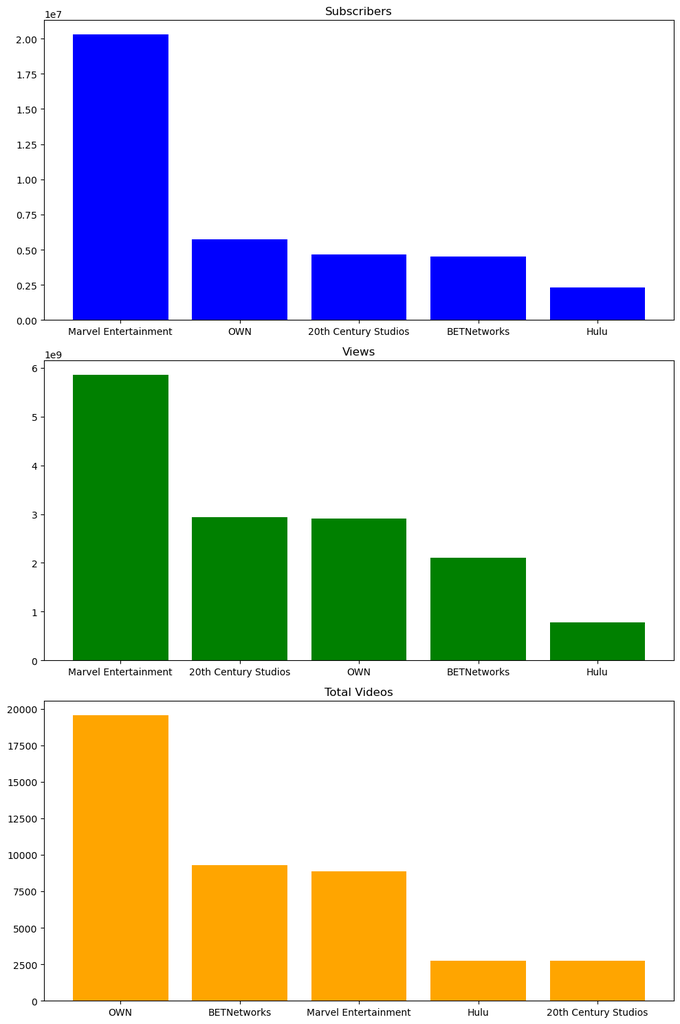

```python
import matplotlib.pyplot as plt

# Sort the DataFrame by 'Subscribers' in descending order
combined_movie_studios_channels_df_subscribers_sorted = combined_movie_studios_channels_df.sort_values(by='Subscribers', ascending=False)

# Plotting Subscribers in descending order
fig, axes = plt.subplots(nrows=3, ncols=1, figsize=(10, 15))

axes[0].bar(combined_movie_studios_channels_df_subscribers_sorted['Channel_name'], combined_movie_studios_channels_df_subscribers_sorted['Subscribers'], color='blue')
axes[0].set_title('Subscribers')

# Sort the DataFrame by 'Views' in descending order
combined_movie_studios_channels_df_views_sorted = combined_movie_studios_channels_df.sort_values(by='Views', ascending=False)

# Plotting Views in descending order
axes[1].bar(combined_movie_studios_channels_df_views_sorted['Channel_name'], combined_movie_studios_channels_df_views_sorted['Views'], color='green')
axes[1].set_title('Views')

# Sort the DataFrame by 'Total_videos' in descending order
combined_movie_studios_channels_df_total_videos_sorted = combined_movie_studios_channels_df.sort_values(by='Total_videos', ascending=False)

# Plotting Total Videos in descending order
axes[2].bar(combined_movie_studios_channels_df_total_videos_sorted['Channel_name'], combined_movie_studios_channels_df_total_videos_sorted['Total_videos'], color='orange')
axes[2].set_title('Total Videos')

# Adjust layout for better visibility
plt.tight_layout()

# Show the plot
plt.show()
```